LaTeX new commands defined for this notebook: $ \newcommand{\bX}{\boldsymbol{X}} \newcommand{\bZ}{\boldsymbol{Z}} \newcommand{\bx}{\boldsymbol{x}} \newcommand{\bz}{\boldsymbol{z}} \newcommand{\btheta}{\boldsymbol{\theta}} \newcommand{\Q}{\mathcal{Q}} \newcommand{\E}{\mathbb{E}} \newcommand{\N}{\mathcal{N}} \newcommand{\bpi}{\boldsymbol{\pi}} \newcommand{\bmu}{\boldsymbol{\mu}} \newcommand{\bSigma}{\boldsymbol{\Sigma}} \newcommand{\L}{\mathcal{L}} \newcommand{\bI}{\boldsymbol{I}} \newcommand{\Mult}{\operatorname{Mult}} \newcommand{\cov}{\operatorname{cov}} \newcommand{\diag}{\operatorname{diag}} \newcommand{\Bern}{\operatorname{Bern}} $

> `\bX` $\bX$, `\bZ` $\bZ$, `\bx` $\bx$, `\bz` $\bz$, `\btheta` $\btheta$, `\Q` $\Q$, `\E` $\E$, `\N` $\N$, `\bpi` $\bpi$, `\bmu` $\bmu$, `\bSigma` $\bSigma$, `\bI` $\bI$, `\L` $\L$, `\Mult` $\Mult$, `\cov` $\cov$, `\diag` $\diag$, `\Bern` $\Bern$

```python
import numpy as np
import matplotlib as mpl
import matplotlib.pyplot as plt
%matplotlib inline

mpl.style.use('seaborn-white')
```

# 9.3 An Alternative View of EM

- 관측 데이터들의 집합을 $N\times D$ 행렬 $\bX$로, 잠재변수들의 집합을 $N\times K$ 행렬 $\bZ$로, 그리고 모수들의 집합을 벡터 $\btheta$로 표시하자. $$ \bX = \begin{pmatrix} \bx_1^T \\ \vdots \\ \bx_N^T \end{pmatrix}, \quad \bZ = \begin{pmatrix} \bz_1^T \\ \vdots \\ \bz_N^T \end{pmatrix} $$
- **EM 알고리즘의 목적**은 잠재변수 $\bZ$를 가지는 모델 $p(\bX|\btheta)$의 모수 $\btheta$를 최대우도추정으로 구하는 것이다. 이때 로그우도함수는 $$ \ln p(\bX|\btheta) = \ln \Bigl\{ \sum_\bZ p(\bX,\bZ|\btheta) \Bigr\} \tag{9.29} $$ 를 사용하고 잠재변수 $\bZ$에 대한 총합(summation)이 로그 안에 들어있다는 사실 때문에 계산이 어렵고 복잡해진다.
- 각 관측 데이터 $\bx_n$에 대응하는 잠재변수 $\bz_n$의 값이 데이터로 함께 주어지면 이 집합 $\{\bX,\bZ\}$를 **완전(complete)데이터**라 한다. (그림 9.9)

[figure not shown]

  완전데이터의 최대우도추정은 로그우도함수 $\ln p(\bX,\bZ|\btheta)$를 사용한다.
- 관측 데이터 $\bX$만 주어지면 **불완전(incomplete)데이터**라 한다. (그림 9.6)

[figure not shown]

  불완전데이터인 경우 $\ln p(\bX,\bZ|\btheta)$를 바로 이용할 수 없으므로 대신 로그우도함수의 기댓값이 최대가 되는 모수 $\btheta^{new}$를 추정한다. (**M step**) $$ \E_\bZ\bigl[\ln p(\bX,\bZ|\btheta)\bigm| \bX\bigr]=\sum_\bZ p(\bZ|\bX)\ln p(\bX,\bZ|\btheta) $$ 그런데 이 기댓값을 구하려면 먼저 잠재변수의 사후 확률분포 $p(\bZ|\bX)$를 알아야 하므로, 이때 모수 $\btheta^{old}$가 필요하다. (**E step**)

### The General EM Algorithm

Given a joint distribution $p(\bX,\bZ|\btheta)$ over observed variables $\bX$ and latent variables $\bZ$, governed by parameters $\btheta$, the goal is to maximize the likelihood function $p(\bX|\btheta)$ with respect to $\btheta$.

1. Choose an initial setting for the parameters $\btheta^{old}$.
2. (**E step**) Evaluate the **posterior distribution of the latent variables** given by $p(\bZ|\bX,\btheta^{old})$.
3. (**M step**) Evaluate $\btheta^{new}$ given by $$ \btheta^{new} = \arg_\btheta\max\Q(\btheta,\btheta^{old}) \tag{9.32} $$ where the **expectation of the complete-data log likelihood** evaluated for some parameter $\btheta$ is denoted by $$ \Q(\btheta,\btheta^{old}) = \E_\bZ\bigl[\ln p(\bX,\bZ|\btheta)\bigm| \bX, \btheta^{old} \bigr] = \sum_{\bZ} p(\bZ|\bX,\btheta^{old}) \ln p(\bX,\bZ|\btheta). \tag{9.33} $$
4. Check for convergence of either the log likelihood or the parameter values. If the convergence criterion is not satisfied, then let $$ \btheta^{old} \leftarrow \btheta^{new} \tag{9.34} $$ and return to Step 2.

## 9.3.1 Gaussian mixtures revisited

### Complete data set

- 가우시안 혼합모델에서 완전데이터 $\{\bX,\bZ\}$가 주어진 경우, 각 데이터 $\bx_n$에 해당하는 잠재변수 데이터 $\bz_n=(z_{n1},\dotsc,z_{nK})^T$은 $\bx_n$이 어떤 성분의 가우시안 확률분포 $\N(\bx|\bmu_k,\bSigma_k)$를 따르는지 알려주는 이진(binary) 값 $z_{nk}$들로 구성되어 있다. (1-of-$K$ coding scheme)
- 성분 $k$에 속한 (즉 $z_{nk}=1$인) 데이터 $\bx_n$들로 이루어진 부분집합을 $\bX_k\subseteq\bX$라 하면, 가우시안 혼합모델의 우도함수는 $$ p(\bX,\bZ|\bpi,\bmu,\bSigma) = \prod_k \prod_{\bx\in\bX_k} \pi_k \N(\bx|\bmu_k,\bSigma_k) = \prod_n \prod_k \pi_k^{z_{nk}} \N(\bx_n|\bmu_k,\bSigma_k)^{z_{nk}} \tag{9.35} $$ 이고, 로그우도함수는 다음과 같다. $$ \ln p(\bX,\bZ|\bpi,\bmu,\bSigma) = \sum_k \Bigl[ |X_k|\ln\pi_k + \sum_{\bx\in\bX_k} \ln\N(\bx|\bmu_k,\bSigma_k) \Bigr] $$
- (**means $\bmu_k$ and covariances $\bSigma_k$**) 평균과 공분산의 최대우도추정은 데이터가 부분집합 $\bX_k$로 주어졌을 때 가우시안 분포 $\N(\bx|\bmu_k,\bSigma_k)$에 대한 최대우도추정과 동일하다. 따라서 $N_k \equiv |\bX_k| = \sum_n z_{nk}$로 두면 \begin{align*} \bmu_k^{ML} &= \frac{1}{N_k} \sum_{\bx\in\bX_k} \bx = \frac{1}{N_k} \sum_n z_{nk} \bx_n \\ \bSigma_k^{ML} &= \frac{1}{N_k} \sum_{\bx\in\bX_k} (\bx-\bmu_k^{ML})(\bx-\bmu_k^{ML})^T = \frac{1}{N_k} \sum_n z_{nk} (\bx_n-\bmu_k^{ML})(\bx_n-\bmu_k^{ML})^T \end{align*}
- (**mixing coefficients $\pi_k$**) 라그랑주 승수법을 이용하면 혼합계수의 최대우도추정은 $$ \pi_k^{ML} = \frac{N_k}{N} = \frac{1}{N} \sum_n z_{nk} \tag{9.37} $$

  > **Proof.** 제한조건 $g(\bpi)=\sum_k \pi_k-1=0$을 만족시키는 로그우도함수 $f(\bpi)=\ln p(\bX,\bZ|\bpi,\bmu,\bSigma)=\sum_k N_k\ln\pi_k + \text{const}$의 최대를 구한다. 라그랑주 함수 $\L(\bpi,\lambda)=f(\bpi)+\lambda g(\bpi)$에 대해 $$ \nabla_{\bpi,\lambda}\L(\bpi,\lambda)=0 \iff \nabla_\bpi f = \lambda\nabla_\bpi g \quad\text{and}\quad g(\bpi)=0 $$ 이므로, 오른쪽 두 식을 만족시키는 $\lambda$를 먼저 찾으면 \begin{align*} \nabla_\bpi f = \lambda\nabla_\bpi &\:\Rightarrow\: \Bigl(\frac{N_1}{\pi_1},\dotsc,\frac{N_K}{\pi_K}\Bigr)^T = \lambda (1,\dotsc,1)^T \\ &\:\Rightarrow\: \lambda = \frac{N_1}{\pi_1} = \dotsb = \frac{N_K}{\pi_K} \end{align*} 이고, 제한조건 $\sum_k \pi_k=1$을 이용하면 $$ \lambda = \lambda \sum_k \pi_k = \sum_k (\lambda \pi_k) = \sum_k N_k = N \:\Rightarrow\: \pi_k=\frac{N_k}{\lambda}=\frac{N_k}{N} $$

### Incomplete data set

가우시안 혼합모델에서 불완전데이터로 $\bX$만 주어진 경우, EM 알고리즘의 일반화를 적용해 보자.

- 베이즈 법칙에 의해 $p(\bZ|\bX) p(\bX) = p(\bX|\bZ) p(\bZ)$이고, 가우시안 혼합모델이 \begin{align*} p(\bZ|\bpi) &= \prod_n \prod_k \pi_k^{z_{nk}} \tag{9.10} \\ p(\bX|\bZ,\bmu,\bSigma) &= \prod_n \prod_k \N(\bx_n|\bmu_k,\bSigma_k)^{z_{nk}} \tag{9.11} \end{align*} 이므로, 사후확률분포는 $$ p(\bZ|\bX,\bpi,\bmu,\bSigma) \propto p(\bX|\bZ,\bmu,\bSigma) p(\bZ|\bpi) = \prod_n \prod_k \bigl[ \pi_k \N(\bx_n|\bmu_k,\bSigma_k) \bigr]^{z_{nk}} \tag{9.38} $$ 또한 (by inspection of the directed graph in Figure 9.6 and making use of the **d-separation criterion** in 8.2.2) $$ p(\bZ|\bX,\bpi,\bmu,\bSigma) = \prod_l p(\bz_l|\bx_l,\bpi,\bmu,\bSigma) \tag{9.80} $$
- (**E step**) 잠재변수의 사후확률 $p(\bZ|\bX)$에 대한 $z_{nk}$의 조건부 기댓값은 데이터 $\bx_n$에 대한 $k$번째 성분의 신뢰도 $\gamma(z_{nk})$와 같다. \begin{align*} \E_\bZ[z_{nk}|\bX] &= \sum_\bZ p(\bZ|\bX) z_{nk} = \sum_{\bz_1}\dotsb\sum_{\bz_N} z_{nk} p(\bz_1|\bx_1) \dotsb p(\bz_N|\bx_N) \\ &= \Bigl( \sum_{\bz_n} z_{nk} p(\bz_n|\bx_n) \Bigr) \cdot \prod_{l\neq n} \Bigl( \sum_{\bz_l} p(\bz_l|\bx_l) \Bigr) = \sum_{\bz_n} z_{nk} p(\bz_n|\bx_n) \\ &= \sum_{\bz_n} z_{nk} \frac{p(\bx_n|\bz_n)p(\bz_n)}{p(\bx_n)} = \frac{\sum_{\bz_n} z_{nk} \prod_i \bigl[ \pi_i \N(\bx_n|\bmu_i,\bSigma_i) \bigr]^{z_{ni}}}{\sum_{\bz_n} \prod_j \bigl[ \pi_j \N(\bx_n|\bmu_j,\bSigma_j) \bigr]^{z_{nj}}} \\ &= \frac{\pi_k \N(\bx_n|\bmu_k,\bSigma_k)}{\sum_j \pi_j \N(\bx_n|\bmu_j,\bSigma_j)} = \gamma(z_{nk}) \tag{9.39} \end{align*} 따라서 신뢰도 $\gamma(z_{nk})$를 계산하는데 모수 $\bpi^{old}$, $\bmu^{old}$, $\bSigma^{old}$가 필요하다.
- (**M step**) 이제 완전데이터 로그우도함수의 기댓값을 구하면 다음과 같다. \begin{align*} \E_\bZ\bigl[ \ln p(\bX,\bZ|\bpi,\bmu,\bSigma) \bigm| \bX \bigr] &= \sum_\bZ p(\bZ|\bX) \ln p(\bX,\bZ|\bpi,\bmu,\bSigma) \\ &= \sum_\bZ p(\bZ|\bX) \sum_n \sum_k z_{nk} \bigl[ \ln\pi_k + \ln\N(\bx_n|\bmu_k,\bSigma_k) \bigr] \\ &= \sum_n \sum_k \Bigl\{ \sum_\bZ p(\bZ|\bX) z_{nk} \Bigr\} \cdot \bigl[ \ln\pi_k + \ln\N(\bx_n|\bmu_k,\bSigma_k) \bigr] \\ &= \sum_n \sum_k \E_\bZ[z_{nk}|\bX] \cdot \bigl[ \ln\pi_k + \ln\N(\bx_n|\bmu_k,\bSigma_k) \bigr] \\ &= \sum_n \sum_k \gamma(z_{nk}) \bigl[ \ln\pi_k + \ln\N(\bx_n|\bmu_k,\bSigma_k) \bigr] \tag{9.40} \end{align*} 이 기댓값을 최대로 만드는 모수는 9.2.2에서 구했던 최대우도추정과 동일하다. \begin{align*} \bmu_k^{new} &= \frac{1}{N_k} \sum_n \gamma(z_{nk}) \bx_n \tag{9.17} \\ \bSigma_k^{new} &= \frac{1}{N_k} \sum_n \gamma(z_{nk}) (\bx_n-\bmu_k^{new})(\bx_n-\bmu_k^{new})^T \tag{9.19} \\ \pi_k^{new} &= \frac{N_k}{N} \quad\text{where}\quad N_k=\sum_n\gamma(z_{nk}) \tag{9.22} \end{align*}

  > **Proof.** (**means $\bmu_k$**) (9.40)을 $\bmu_k$에 대한 함수로 다시 기술하면 $$ \E_\bZ\bigl[ \ln p(\bX,\bZ|\bpi,\bmu,\bSigma) \bigm| \bX \bigr] = -\frac{1}{2} \sum_n \sum_j \gamma(z_{nj}) (\bx_n-\bmu_j)^T \bSigma_j^{-1} (\bx_n-\bmu_j) + \text{const} $$ 이므로 $\bmu_k$에 대해 미분한 후, 양변에 $\bSigma_k$를 곱한 다음 0이 되는 값을 구한다. $$ \sum_n \gamma(z_{nk}) \bSigma_k^{-1} (\bx_n-\bmu_k) = 0 \:\Rightarrow\: \sum_n \gamma(z_{nk}) (\bx_n-\bmu_k) = 0 \:\Rightarrow\: \bmu_k = \frac{\sum_n \gamma(z_{nk}) \bx_n}{\sum_n \gamma(z_{nk})} = \frac{\sum_n \gamma(z_{nk}) \bx_n}{N_k} $$

## 9.3.2 Relation to $K$-means

가우시안 혼합모델에서 $K$-평균 알고리즘은 클러스터 센터(평균) $\bmu_k$를 찾는데 반해 EM 알고리즘은 여기에 더해 혼합계수 $\pi_k$와 공분산 $\bSigma_k$까지 찾는다. 또한 $K$-평균 알고리즘이 각 데이터가 어느 클러스터에 속하는지 라벨로 (견고하게) 알려주는데 반해 EM 알고리즘은 신뢰도를 이용해 (느슨하게) 클러스터를 지정한다. 두 알고리즘은 유사한 모습을 가지고 있는데, 사실 $K$-평균 알고리즘은 EM 알고리즘의 특별한 (극한) 형태로 볼 수 있다.

- 가우시안 혼합모델에서 모든 공분산을 $\bSigma_k=\epsilon\bI$로 두고 EM 알고리즘의 일반화를 적용해 보자.
- (**E step**) 데이터 $\bx_n$에 대한 $k$번째 성분의 신뢰도 $\gamma(z_{nk})$의 극한은 클러스터 라벨 $r_{nk}$가 된다. \begin{align*} \gamma(z_{nk}) &= \frac{\pi_k \N(\bx_n|\bmu_k,\bSigma_k)}{\sum_j \pi_j \N(\bx_n|\bmu_j,\bSigma_j)} = \frac{\pi_k \exp\{-\|\bx_n-\bmu_k\|^2/2\epsilon\}}{\sum_j \pi_j \exp\{-\|\bx_n-\bmu_j\|^2/2\epsilon\}} \tag{9.42} \\ &\to r_{nk} = \begin{cases} 1 & \text{if $k=\arg\min_j\|\bx_n-\bmu_j\|^2$} \\ 0 & \text{otherwise} \end{cases} \tag{9.2} \quad\text{as}\quad \epsilon\to 0 \end{align*}

  > **Proof.** $k_0=\arg\min_j\|\bx_n-\bmu_j\|^2$라 두면 \begin{align*} \frac{\exp\{-\|\bx_n-\bmu_j\|^2/2\epsilon\}}{\exp\{-\|\bx_n-\bmu_{k_0}\|^2/2\epsilon\}} &= \exp\Bigl\{\frac{\|\bx_n-\bmu_{k_0}\|^2-\|\bx_n-\bmu_j\|^2}{2\epsilon}\Bigr\} \\ &\to \begin{cases} 1 & \text{if $j=k_0$} \\ 0 & \text{otherwise} \end{cases} \quad\text{as}\quad \epsilon\to0 \end{align*} 따라서 (9.42)의 분자와 분모 모두를 $\exp\{-\|\bx_n-\bmu_{k_0}\|^2/2\epsilon\}$로 나누고 극한을 구하면 된다.
- (**M step**) (9.17)에서 최대우도추정으로 구한 $\bmu_k^{new}$의 극한은 클러스터 센터가 된다. $$ \bmu_k^{new} \to \frac{1}{N_k}\sum_n r_{nk}\bx_n \quad\text{as}\quad \epsilon\to 0 \tag{9.4} $$
- (**distortion measure; inertia**) 완전데이터 로그우도함수의 기댓값 (9.40)에 $\epsilon>0$을 곱하면 \begin{align*} \E_\bZ\bigl[\ln p(\bX,\bZ|\bpi,\bmu,\bSigma) \bigm| \bX \bigr] &= \sum_n \sum_k \gamma(z_{nk}) \ln \N(\bx_n|\bmu_k,\bSigma_k) + \text{const} \\ \epsilon \cdot \E_\bZ\bigl[\ln p(\bX,\bZ|\bpi,\bmu,\bSigma) \bigm| \bX \bigr] &= -\frac{1}{2} \sum_n \sum_k \gamma(z_{nk}) \| \bx_n-\bmu_k \|^2 + \epsilon\cdot\text{const} + \epsilon\ln\epsilon\cdot\text{const} \\ &\to -\frac{1}{2} \sum_n \sum_k r_{nk} \| \bx_n-\bmu_k \|^2 \quad\text{as}\quad \epsilon\to0 \tag{9.43} \end{align*} EM 알고리즘은 기댓값의 최대를 찾으므로 $\epsilon$을 곱해도 알고리즘이 작동하는데 전혀 영향을 받지 않는다. 따라서 $\epsilon\to0$이 되면 이 기댓값을 최대로 만드는 것은 $K$-평균 알고리즘에서 $J$의 최소를 구하는 것과 동일함을 알 수 있다.

## 9.3.3 Mixtures of Bernoulli distributions

### Multivariate Bernoulli distribution

- Consider a set of $D$ binary variables $x_i$, each of which is governed by a Bernoulli distribution with parameter $\mu_i$, so that $$ \Bern(\bx|\bmu) = \prod_i \mu_i^{x_i}(1-\mu_i)^{(1-x_i)} \tag{9.44} $$
- The mean and covariance of this distribution are \begin{align*} \E[\bx] &= \bmu \tag{9.45} \\ \cov[\bx] &= \diag\{ \mu_i(1-\mu_i) \} \tag{9.46} \end{align*}

### Mixtures of multivariate Bernoulli distributions

- 베르누이 혼합모델의 확률질량함수는 $$ p(\bx|\bpi,\bmu) = \sum_k \pi_k \Bern(\bx|\bmu_k) \tag{9.47} $$ 이고, 평균과 공분산은 \begin{align*} \E[\bx] &= \sum_k \pi_k \bmu_k \tag{9.49} \\ \cov[\bx] &= \sum_k \pi_k \bigl\{ \bSigma_k + \bmu_k\bmu_k^T \bigr\} - \E[\bx]\E[\bx]^T \tag{9.50} \end{align*} where $\bSigma_k=\diag\{ \mu_{ki}(1-\mu_{ki}) \}$.

  > 공분산 $\cov[\bx]$는 대각행렬이 아니므로, 베르누이 혼합모델이 확률변수들 사이의 상관관계를 가지고 있음을 알 수 있다.
- 관측 데이터 $\{\bx_1,\dotsc,\bx_N\}$들로 이루어진 행렬 $\bX$가 주어졌을 때 베르누이 혼합모델의 로그우도함수 $$ \ln p(\bX|\bpi,\bmu) = \sum_n \ln \Bigl\{ \sum_k \pi_k \Bern(\bx_n|\bmu_k) \Bigr\} \tag{9.51} $$ 는 로그 안에 총합을 포함하고 있으므로 단순한(closed) 형태의 최대우도추정 식을 얻을 수 없다.

### EM algorithm of Bernoulli mixtures

- 가우시안 혼합모델과 동일하게 $\sum_k z_k=1$인 $K$차원 이진변수 $\bz=(z_1,\dotsc,z_K)^T$를 잠재변수로 도입하면 사전확률분포와 조건부분포는 \begin{align*} p(\bz|\bpi) &= \prod_k \pi_k^{z_k} \tag{9.53} \\ p(\bx|\bz,\bmu) &= \prod_k \Bern(\bx|\bmu_k)^{z_k} \tag{9.52} \end{align*}
- 결합분포를 주변화(marginalization) 하면 (9.47)과 동일한 결과를 얻는다. \begin{align*} p(\bx|\bpi,\bmu) &= \sum_\bz p(\bx,\bz|\bpi,\bmu) = \sum_\bz p(\bz|\bpi) p(\bx|\bz,\bmu) \\ &= \sum_\bz \prod_k \bigl[ \pi_k \Bern(\bx|\bmu_k) \bigr]^{z_k} = \sum_k \pi_k \Bern(\bx|\bmu_k) \end{align*}
- (**E step**) 잠재변수의 사후확률 $p(\bZ|\bX)$에 대한 $z_{nk}$의 조건부 기댓값은 데이터 $\bx_n$에 대한 $k$번째 성분의 신뢰도 $\gamma(z_{nk})$와 같다. $$ \gamma(z_{nk}) \equiv \E_\bZ[z_{nk}|\bX] = \sum_{\bz_n} z_{nk} \frac{p(\bx_n|\bz_n)p(\bz_n)}{p(\bx_n)} = \frac{\sum_{\bz_n} z_{nk} \prod_i \bigl[ \pi_i \Bern(\bx_n|\bmu_i) \bigr]^{z_{ni}}}{\sum_{\bz_n} \prod_j \bigl[ \pi_j \Bern(\bx_n|\bmu_j) \bigr]^{z_{nj}}} = \frac{\pi_k \Bern(\bx_n|\bmu_k)}{\sum_j \pi_j \Bern(\bx_n|\bmu_j)} \tag{9.39} $$ 신뢰도 $\gamma(z_{nk})$를 계산하는데 모수 $\pi_k^{old}$와 $\bmu_k^{old}$가 필요하다.
- (**M step**) 이제 완전데이터 로그우도함수의 기댓값을 구하면 다음과 같다. \begin{align*} \ln p(\bX,\bZ|\bpi,\bmu) = \sum_n \sum_k z_{nk} \Bigl\{ \ln\pi_k + \sum_i \bigl[ x_{ni}\ln\mu_{ki} + (1-x_{ni})\ln(1-\mu_{ki}) \bigr] \Bigr\} \tag{9.54} \\ \E_\bZ\bigl[ \ln p(\bX,\bZ|\bpi,\bmu) \bigm| \bX \bigr] = \sum_n \sum_k \gamma(z_{nk}) \Bigl\{ \ln\pi_k + \sum_i \bigl[ x_{ni}\ln\mu_{ki} + (1-x_{ni})\ln(1-\mu_{ki}) \bigr] \Bigr\} \tag{9.55} \end{align*} 이 기댓값을 최대로 만드는 모수는 가우시안 혼합모델과 동일하다. \begin{align*} \bmu_k^{new} &= \bar{\bx}_k = \frac{1}{N_k} \sum_n \gamma(z_{nk}) \bx_n \tag{9.58} \\ \pi_k^{new} &= \frac{N_k}{N} \quad\text{where}\quad N_k=\sum_n\gamma(z_{nk}) \tag{9.60} \end{align*}
- 가우시안 혼합모델과 달리 베르누이 혼합모델에서는 우도함수가 무한대로 가는 특이점 문제가 발생하지 않는다. 베르누이 분포에서 확률질량은 $0\leq \Bern(\bx_n|\bmu_k)\leq 1$이므로 혼합모델의 우도함수 $p(\bx_n)=\sum_j \pi_j \Bern(\bx_n|\bmu_j)$도 상계가 정해지기 때문이다. 또한 우도함수가 0이 되는 특이점도 초기값에서 이러한 문제가 발생하지 않도록 설정하면 다시 나타나지 않는다. EM 알고리즘은 우도함수가 증가하는 방향으로 모수를 찾기 때문이다.

```
Number of samples = [(2, 199), (3, 222), (4, 179)]
```

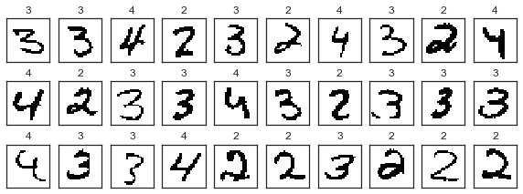

```python
from sklearn.datasets import fetch_mldata
mnist = fetch_mldata('MNIST original')

# We now fit a data set of N = 600 such digits, comprising
# the digits ‘2’, ‘3’, and ‘4’.
N = 600
indices = np.random.choice(
    np.where((mnist.target >= 2) & (mnist.target <= 4))[0], size=N)
target = mnist.target[indices]
data = mnist.data[indices] / 255
# Here the digit images have been turned into binary vectors
# by setting all elements whose values exceed 0.5 to 1. and
# setting the remaining elements to 0.
mask = data > 0.5
data[mask] = 1.0
data[~mask] = 0.0

def draw_a_digit(ax, data, title):
    ax.imshow(data.reshape((28, 28)))
    ax.set_title(title)
    ax.tick_params(labelbottom=False, labelleft=False)

print('Number of samples = {}'.format(
    [(k, np.count_nonzero(target == k)) for k in (2, 3, 4)] ))

nrows = 3
ncols = 10
fig, ax = plt.subplots(nrows, ncols, figsize=(10,nrows*1.2))
ax = ax.ravel()
for i in range(nrows*ncols):
    n = np.random.randint(N)
    draw_a_digit(ax[i], data[n], str(int(target[n])))
```

```
Initial pi = [0.33333333 0.33333333 0.33333333]
```

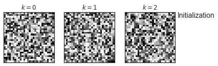

```python
from scipy.stats import uniform

K = 3
D = data.shape[1] # 28 by 28

# The mixing coefficients were initialized to $\pi_k = 1/K$, and the parameters
# $\mu_{kj}$ were set to random values chosen uniformly in the range (0.25, 0.75)
# and then normalized to satisfy the constraint that $\sum_j \mu_{kj}=1$.
pi_init = np.repeat(1/K, K) # shape (K,)
x = uniform.rvs(loc=0.25, scale=0.5, size=(D, K))
mu_init = (x / np.sum(x, axis=0)).T # shape (K, D)

def draw_components(x, text=None):
    fig, ax = plt.subplots(ncols=K, figsize=(K*2,2))
    for k in range(K):
        draw_a_digit(ax[k], x[k], '$k={}$'.format(k))
    ax[-1].text(1.05, 0.9, text, fontsize=14, transform=ax[-1].transAxes)

print('Initial pi = {}'.format(pi_init))
draw_components(mu_init, text='Initialization')
```

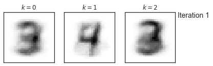

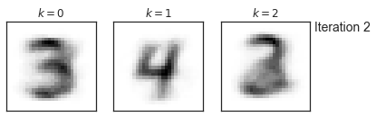

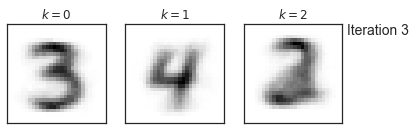

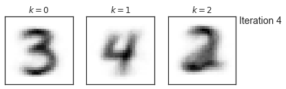

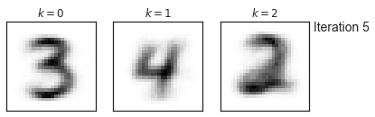

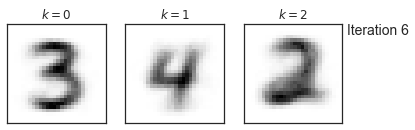

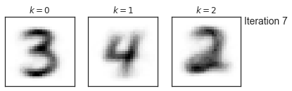

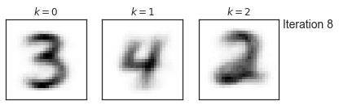

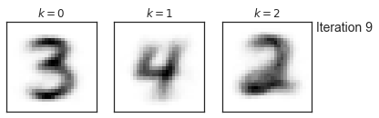

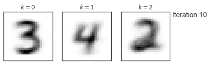

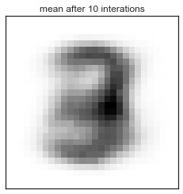

```python
from scipy.special import xlogy, xlog1py, logsumexp

# x=(N, D), pi=(K,), mu=(K, D), resp=(N, K)

# much faster than scipy.stats.bernoulli
def log_multi_bernoulli(x, mu):
    assert x.shape[-1] == mu.shape[-1]
    return np.sum(xlogy(x[:,np.newaxis], mu) +
                  xlog1py(1 - x[:,np.newaxis], -mu), axis=-1) # shape (N, K)

def E_step(x, pi, mu):
    assert pi.shape[0] == mu.shape[0]
    z = np.log(pi) + log_multi_bernoulli(x, mu) # shape (N, K)
    return np.exp(z - logsumexp(z, axis=1)[:,np.newaxis]) # shape (N, K)

def M_step(x, resp):
    assert x.shape[0] == resp.shape[0]
    N_k = np.sum(resp, axis=0)
    pi = N_k / x.shape[0]
    mu = np.sum(resp[:,:,np.newaxis] * x[:,np.newaxis,:], axis=0) / N_k[:,np.newaxis]
    return pi, mu

mu = mu_init
pi = pi_init

n_times = 10
for i in range(n_times):
    resp = E_step(data, pi, mu)
    pi, mu = M_step(data, resp)
    draw_components(mu, text='Iteration {}'.format(i+1))

fig, ax = plt.subplots()
draw_a_digit(ax, mu.mean(axis=0), 'mean after {} interations'.format(n_times))
```

**Figure 9.10** Illustration of the Bernoulli mixture model in which the top row shows examples from the digits data set after converting the pixel values from grey scale to binary using a threshold of 0.5. On the bottom row the first three images show the parameters $\mu_{ki}$ for each of the three components in the mixture model. As a comparison, we also fit the same data set using a single multivariate Bernoulli distribution, again using maximum likelihood. This amounts to simply averaging the counts in each pixel and is shown by the right-most image on the bottom row.